# Interpolation for Missing Data

An overview to various Interpolation methods for missing data. Demo in Time-series records with `NaN` entries.

Published by Sun CHUNG, *SMIEEE* M.Sc. HKU - *colab w/ MIT-IDSS*

### CONTENT

[Bacic] - **Linear Interpolation**

[Advanced] - **Curved Interpolation**:

- Polynomial Interpolation
- Spline Interpolation

**Dealing with Seasonal Data**:

- Seasonal Decomposition of Time Series
- Filling Missing Values Using Seasonal Decomposition

**Machine Learning for Imputation**:

- Using K-Nearest Neighbors to Impute Missing Values

**Notes for Data Engineers**

**Demo & Comparison**

# Linear Interpolation

Linear interpolation is a method to estimate missing values within a dataset by using the values of neighboring data points. In the context of time series data, such as daily sales, linear interpolation involves estimating a missing value by connecting the dots between the known values immediately before and after the missing value.

### Essential Libraries for Linear Interpolation:

```
import pandas as pd
import numpy as np
import matplotlib.pyplot as plt
```

## Step-by-step Explanation:

### 1. Load the Dataset:

Load the time series data, which includes some missing values. (Prepared with `np.nan` values contained by `pd.DataFrame`

#### [code]

```
# Sample (time series) data with missing values -
dates = pd.date_range(start='2020-01-01', end='2020-01-10')
sales = [200, np.nan, 210, np.nan, np.nan, 250, 260, np.nan, 280, 290]
data = pd.DataFrame({'date': dates, 'sales': sales})
```

```
Original Data:
```

|  | date | sales |
| --- | --- | --- |
| 0 | 2020-01-01 | 200.0 |
| 1 | 2020-01-02 | NaN |
| 2 | 2020-01-03 | 210.0 |
| 3 | 2020-01-04 | NaN |
| 4 | 2020-01-05 | NaN |
| 5 | 2020-01-06 | 250.0 |
| 6 | 2020-01-07 | 260.0 |
| 7 | 2020-01-08 | NaN |
| 8 | 2020-01-09 | 280.0 |
| 9 | 2020-01-10 | 290.0 |

### 2. Identify Missing Values:

Identify the positions of the missing values in the dataset.

```
Missing Values in Each Column:
date     0
sales    4
dtype: int64
Percentage of Missing Data: 40.00%
```

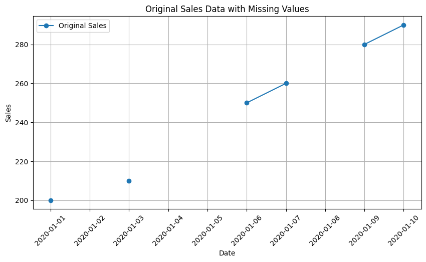

### 3. Apply Linear Interpolation:

Use linear interpolation to estimate the missing values based on the surrounding data points.

#### [Code]

```
data['sales_interpolated'] = data['sales'].interpolate(method='linear')
```

```
Data After Linear Interpolation:
        date  sales  sales_interpolated
0 2020-01-01  200.0          200.000000
1 2020-01-02    NaN          205.000000
2 2020-01-03  210.0          210.000000
3 2020-01-04    NaN          223.333333
4 2020-01-05    NaN          236.666667
5 2020-01-06  250.0          250.000000
6 2020-01-07  260.0          260.000000
7 2020-01-08    NaN          270.000000
8 2020-01-09  280.0          280.000000
9 2020-01-10  290.0          290.000000
```

### 4. Visualize the Results:

Plot the original and interpolated data to visualize the impact of linear interpolation.

#### [Code]

```
plt.plot(data['date'], data['sales'], label='Original Sales', marker='o')
plt.plot(data['date'], data['sales_interpolated'], label='Interpolated Sales', marker='x')
```

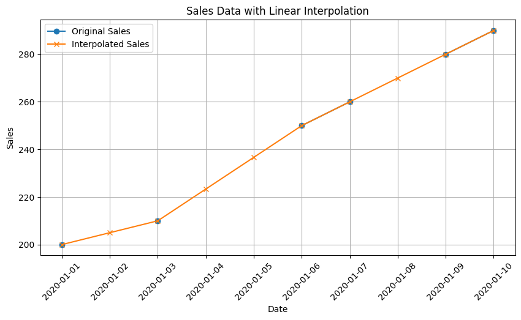

## `Linear Interpolation` approach takeaways:

### Reporting Missing Data:

Calculate and print the percentage of missing data. Visualize the original data to assess if the data shape is suitable for linear interpolation.

### Visualizing the Data:

Plot the original data to observe any trends or patterns, which helps in deciding if applying linear interpolation is appropriate.

By following these enhanced steps, you can provide a more comprehensive analysis and ensure that linear interpolation is suitable for the dataset.

### Verdict:

Linear interpolation is a simple and effective method for estimating missing values when the data is relatively smooth and exhibits linear trends between data points.

### Considerations:

- Suitability: Best for datasets with short periods of missing values and linear trends.
- Advantages: Easy to implement and understand; computationally inexpensive.
- Limitations: May not capture complex patterns or non-linear trends in the data.
- Example Use Case: Daily sales data where sales generally follow a linear trend over short periods, or time-gaps.

Back to Top

# [Advanced] - Missing Data in Time

# ReBuild Complex Time-series Data:

### Sample (Advanced) Dataset

```
dates = pd.date_range(start='2020-01-01', end='2020-01-20')
sales = [200, np.nan, 210, np.nan, np.nan, 250, 260, np.nan, 280, 290,
         285, np.nan, 280, 270, np.nan, np.nan, 320, 325, np.nan, 330]
```

```
Original Data:
         date  sales
0  2020-01-01  200.0
1  2020-01-02    NaN
2  2020-01-03  210.0
3  2020-01-04    NaN
4  2020-01-05    NaN
5  2020-01-06  250.0
6  2020-01-07  260.0
7  2020-01-08    NaN
8  2020-01-09  280.0
9  2020-01-10  290.0
10 2020-01-11  285.0
11 2020-01-12    NaN
12 2020-01-13  280.0
13 2020-01-14  270.0
14 2020-01-15    NaN
15 2020-01-16    NaN
16 2020-01-17  320.0
17 2020-01-18  325.0
18 2020-01-19    NaN
19 2020-01-20  330.0
```

### 0. Identify and Report Missing Values

```
Missing Values in Each Column:
date     0
sales    8
dtype: int64
Percentage of Missing Data: 40.00%
```

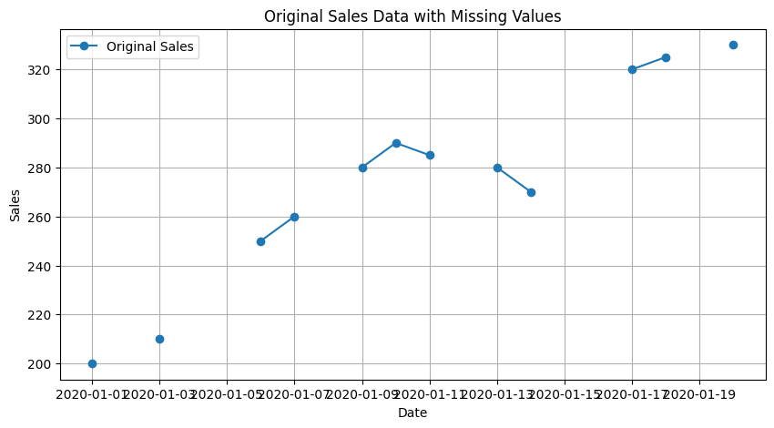

# Polynomial Interpolation

```
Data After Polynomial Interpolation (Order 2):
         date  sales  sales_poly
0  2020-01-01  200.0  200.000000
1  2020-01-02    NaN  202.744901
2  2020-01-03  210.0  210.000000
3  2020-01-04    NaN  221.765298
4  2020-01-05    NaN  237.060075
5  2020-01-06  250.0  250.000000
6  2020-01-07  260.0  260.000000
7  2020-01-08    NaN  269.433955
8  2020-01-09  280.0  280.000000
9  2020-01-10  290.0  290.000000
10 2020-01-11  285.0  285.000000
11 2020-01-12    NaN  283.418194
12 2020-01-13  280.0  280.000000
13 2020-01-14  270.0  270.000000
14 2020-01-15    NaN  277.891996
15 2020-01-16    NaN  303.356190
16 2020-01-17  320.0  320.000000
17 2020-01-18  325.0  325.000000
18 2020-01-19    NaN  327.808221
19 2020-01-20  330.0  330.000000
```

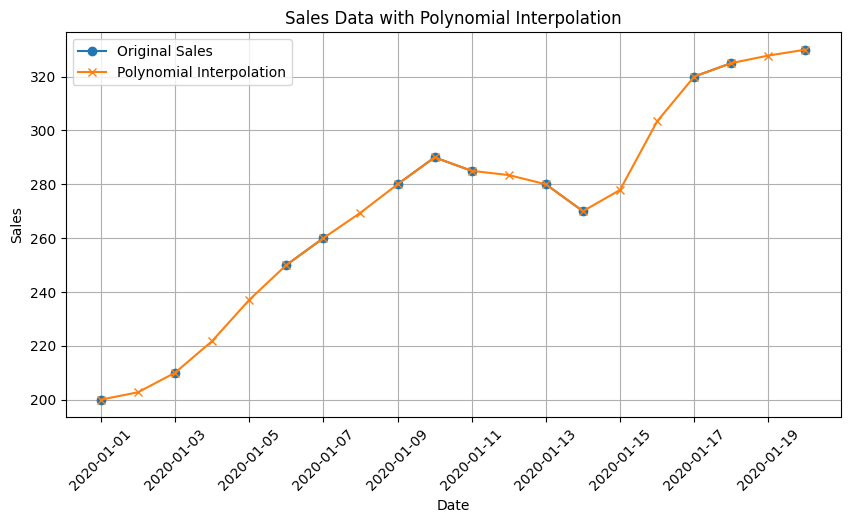

# Spline Interpolation

```
Data After Spline Interpolation (Order 3):
         date  sales  sales_spline
0  2020-01-01  200.0    200.000000
1  2020-01-02    NaN    202.501863
2  2020-01-03  210.0    210.000000
3  2020-01-04    NaN    221.744115
4  2020-01-05    NaN    235.112441
5  2020-01-06  250.0    250.000000
6  2020-01-07  260.0    260.000000
7  2020-01-08    NaN    271.175964
8  2020-01-09  280.0    280.000000
9  2020-01-10  290.0    290.000000
10 2020-01-11  285.0    285.000000
11 2020-01-12    NaN    284.015769
12 2020-01-13  280.0    280.000000
13 2020-01-14  270.0    270.000000
14 2020-01-15    NaN    280.623322
15 2020-01-16    NaN    301.420996
16 2020-01-17  320.0    320.000000
17 2020-01-18  325.0    325.000000
18 2020-01-19    NaN    325.170975
19 2020-01-20  330.0    330.000000
```

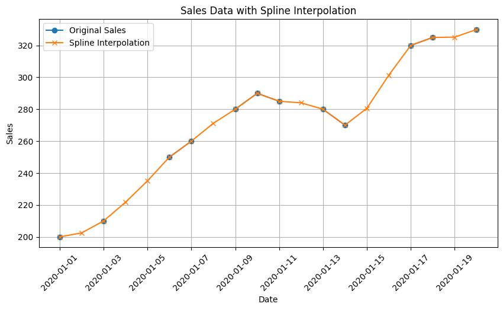

## `Polynomial` and `Spline Interpolation` approach takeaways:

### Verdicts

- **Polynomial interpolation** fits a polynomial of a specified order, or complex curves through the known data points, making it suitable for datasets with non-linear trend.
- **Spline interpolation** fits piecewise polynomials between data points, ensuring smooth transitions. It is effective for capturing complex patterns without the risk of overfitting.

### Considerations:

#### Polynomial Interpolation -

- Suitability: Appropriate for datasets with non-linear trends and where the relationship between data points can be approximated by a polynomial.
- Advantages: Captures more complex patterns compared to linear interpolation.
- Limitations: Higher-order polynomials can lead to overfitting and oscillations between data points (Runge's phenomenon).
- Example Use Case: Sales data with noticeable but smooth non-linear trends over time.

#### Spline Interpolation -

- Suitability: Ideal for datasets with complex, smooth trends where continuity and smoothness are essential.
- Advantages: Provides smooth and continuous estimates; avoids oscillations associated with higher-order polynomials.
- Limitations: Requires more computational effort than linear interpolation. Example Use Case: Seasonal sales data with smooth but complex fluctuations.

Back to Top

# Dealing with Seasonal Data:

## Sample (Synthetic Seasonal) Data

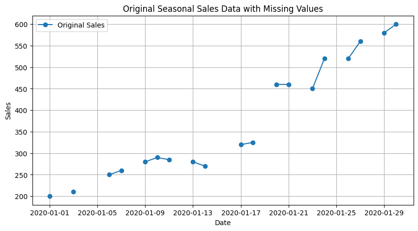

# Seasonal Decomposition:

## Plotting decomposition components

#### [Code] - weekly season, as `period = 7` (days) in this sample data by on running dates

```
decomposition = seasonal_decompose(seasonal_data['sales'], model='additive', period=7)

# CHOOSING THE SUITABLE MODEL
# 'additive': Assumes that the seasonal fluctuations are constant throughout the series. This is suitable when the magnitude of seasonal variations does not change with the level of the time series.
# 'multiplicative': Assumes that the seasonal fluctuations are proportional to the level of the time series. This is appropriate when the magnitude of seasonal variations increases or decreases with the level of the time series.
# These are TWO models in Seasonal Decomposition -
#  model='additive' ||  model='multiplicative'

# CHOOSE THE MOVING AVERAGE
two_sided=True: The moving average is calculated using data points both before and after the current point. This is a centered moving average.
two_sided=False: The moving average is calculated using only data points before the current point. This is a trailing moving average.
# These are TWO average in Seasonal Decomposition -
#  two_sided=True || model='additive'
```

```
Seasonal Decomposition Components:
            sales  additive_sales       trend   seasonal      resid  \
date
2020-01-01  200.0      200.000000         NaN  -4.725057        NaN
2020-01-02    NaN      205.000000         NaN -10.994898        NaN
2020-01-03  210.0      210.000000         NaN   6.465420        NaN
2020-01-04    NaN      223.333333  226.428571  -6.808390   3.713152
2020-01-05    NaN      236.666667  236.428571  -0.796485   1.034580
2020-01-06  250.0      250.000000  247.142857  14.679705 -11.822562
2020-01-07  260.0      260.000000  258.571429   2.179705  -0.751134
2020-01-08    NaN      270.000000  267.380952  -4.725057   7.344104
2020-01-09  280.0      280.000000  273.928571 -10.994898  17.066327
2020-01-10  290.0      290.000000  278.214286   6.465420   5.320295
2020-01-11  285.0      285.000000  279.642857  -6.808390  12.165533
2020-01-12    NaN      282.500000  282.023810  -0.796485   1.272676
2020-01-13  280.0      280.000000  285.357143  14.679705 -20.036848
2020-01-14  270.0      270.000000  289.642857   2.179705 -21.822562
2020-01-15    NaN      286.666667  295.357143  -4.725057  -3.965420

            sales_filled  interpolated_sales
date
2020-01-01    200.000000          200.000000
2020-01-02      0.978846          205.000000
2020-01-03    210.000000          210.000000
2020-01-04      0.980656          223.333333
2020-01-05      1.001169          236.666667
2020-01-06    250.000000          250.000000
2020-01-07    260.000000          260.000000
2020-01-08      0.988959          270.000000
2020-01-09    280.000000          280.000000
2020-01-10    290.000000          290.000000
2020-01-11    285.000000          285.000000
2020-01-12      1.001169          282.500000
2020-01-13    280.000000          280.000000
2020-01-14    270.000000          270.000000
2020-01-15      0.988959          286.666667
```

[figure not shown]

## Filling Missing Values (by Season Decomposition)

```
Data After Filling Missing Values Using Trend Component:
                 sales  sales_filled
date
2020-01-01  200.000000    200.000000
2020-01-02         NaN           NaN
2020-01-03  210.000000    210.000000
2020-01-04  226.428571    226.428571
2020-01-05  236.428571    236.428571
2020-01-06  250.000000    250.000000
2020-01-07  260.000000    260.000000
2020-01-08  267.380952    267.380952
2020-01-09  280.000000    280.000000
2020-01-10  290.000000    290.000000
2020-01-11  285.000000    285.000000
2020-01-12  282.023810    282.023810
2020-01-13  280.000000    280.000000
2020-01-14  270.000000    270.000000
2020-01-15  295.357143    295.357143
2020-01-16  311.071429    311.071429
2020-01-17  320.000000    320.000000
2020-01-18  325.000000    325.000000
2020-01-19  387.976190    387.976190
2020-01-20  460.000000    460.000000
2020-01-21  460.000000    460.000000
2020-01-22  465.357143    465.357143
2020-01-23  450.000000    450.000000
2020-01-24  520.000000    520.000000
2020-01-25  513.571429    513.571429
2020-01-26  520.000000    520.000000
2020-01-27  560.000000    560.000000
2020-01-28         NaN           NaN
2020-01-29  580.000000    580.000000
2020-01-30  600.000000    600.000000
```

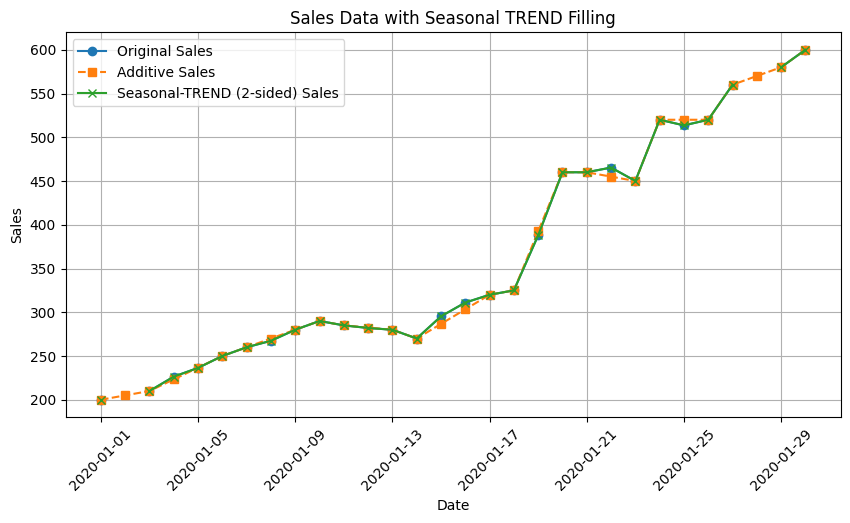

## `Seasonal Decomposition` approach takeaways:

### Verdict:

Seasonal decomposition is highly effective for time series data with clear seasonal patterns. It separates the data into trend, seasonal, and residual components, allowing for targeted imputation.

Filling missing values using the `trend` component can be effective in seasonal data.

### Considerations -

- Suitability: Best for datasets with strong seasonal components.
- Advantages: Provides a clear understanding of underlying patterns; allows for more accurate imputation by leveraging trend and seasonal components.
- Limitations: Requires identifying the correct seasonal period; may be complex to implement.
- Example Use Case: Retail sales data with weekly or monthly seasonality.

Back to Top

# Machine Learning (for Imputation)

## Sample Data (with more complexity):

```
        Date  Feature1  Feature2  Feature3  Feature4
0 2023-01-01  0.384773  0.859708  0.944200  0.702825
1 2023-01-02  0.633634  0.605961  0.200127  0.387388
2 2023-01-03  0.258983  0.074607  0.280957  0.438434
3 2023-01-04  0.483249  0.868489  0.529629  0.562263
4 2023-01-05  0.471055  0.688842  0.504829  0.823176
```

## Inroduce missing values (randomized `NaN`):

```
         Date  Feature1  Feature2  Feature3  Feature4
0  2023-01-01       NaN  0.859708  0.944200  0.702825
1  2023-01-02  0.633634  0.605961  0.200127  0.387388
2  2023-01-03  0.258983  0.074607  0.280957       NaN
3  2023-01-04  0.483249  0.868489  0.529629  0.562263
4  2023-01-05  0.471055  0.688842  0.504829  0.823176
5  2023-01-06  0.960367       NaN  0.309176  0.549721
6  2023-01-07       NaN       NaN       NaN  0.448535
7  2023-01-08  0.799273  0.728354  0.088146  0.793035
8  2023-01-09  0.923164  0.614906  0.210786  0.241641
9  2023-01-10  0.413179  0.729189  0.015090  0.184279
10 2023-01-11  0.443033  0.598399  0.127193  0.811845
11 2023-01-12  0.217879  0.090426  0.121168  0.991998
12 2023-01-13  0.323992  0.401741  0.478738  0.417705
13 2023-01-14  0.294813  0.569507  0.363286  0.250070
14 2023-01-15       NaN  0.601268  0.329458  0.648316
```

# Using K-Nearest Neighbors (KNN) for Imputation:

```
n_neighbors=5, weights='uniform'
```

```
         Date  Feature1  Feature2  Feature3  Feature4
0  2023-01-01  0.586534  0.859708  0.944200  0.702825
1  2023-01-02  0.633634  0.605961  0.200127  0.387388
2  2023-01-03  0.258983  0.074607  0.280957  0.512812
3  2023-01-04  0.483249  0.868489  0.529629  0.562263
4  2023-01-05  0.471055  0.688842  0.504829  0.823176
5  2023-01-06  0.960367  0.469832  0.309176  0.549721
6  2023-01-07  0.481455  0.410190  0.550725  0.448535
7  2023-01-08  0.799273  0.728354  0.088146  0.793035
8  2023-01-09  0.923164  0.614906  0.210786  0.241641
9  2023-01-10  0.413179  0.729189  0.015090  0.184279
10 2023-01-11  0.443033  0.598399  0.127193  0.811845
11 2023-01-12  0.217879  0.090426  0.121168  0.991998
12 2023-01-13  0.323992  0.401741  0.478738  0.417705
13 2023-01-14  0.294813  0.569507  0.363286  0.250070
14 2023-01-15  0.335405  0.601268  0.329458  0.648316
```

# Visualize the KNN Imputation (Before & After)

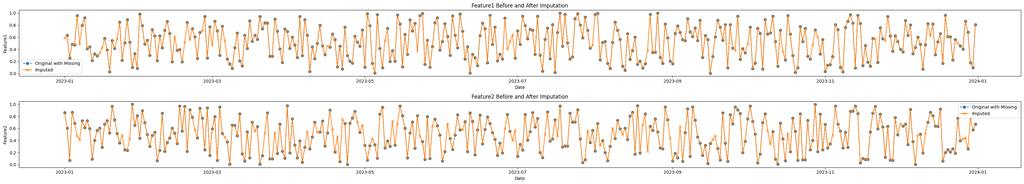

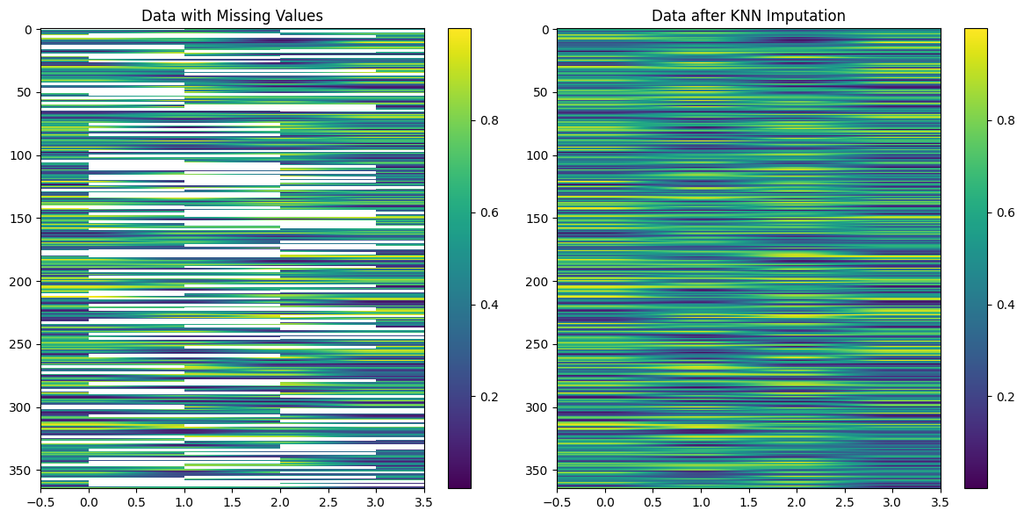

## `K-Nearest Neighbors (KNN)` approach takeaways:

KNN imputation estimates missing values based on the values of the nearest neighbors in the dataset.

### Verdict:

KNN imputation is a versatile method that estimates missing values based on the similarity to other data points. It can capture local patterns in the data.

### Concerations:

- Suitability: Suitable for datasets where missing values can be reasonably approximated by the nearest neighbors.
- Advantages: Can handle non-linear and complex relationships; leverages information from multiple data points.
- Limitations: Computationally intensive; performance depends on the choice of neighbors and distance metric.
- Example Use Case: Retail sales data with missing values that follow patterns similar to those of neighboring days.

Back to Top

# Notes for Data Engineers -

1. Data Characteristics: Understand the characteristics of data (e.g., trends, seasonality, smoothness) to choose the most appropriate interpolation method.
2. Visualization: Always visualize your data before and after applying interpolation to ensure the method captures the underlying patterns accurately.
3. Model Evaluation: Evaluate the performance of different interpolation methods using appropriate metrics (e.g., RMSE, MAE) to select the best approach. Computational Resources: Consider the computational cost of the interpolation method, especially for large datasets.
4. Combining Methods: In some cases, combining multiple methods (e.g., spline interpolation for short gaps and seasonal decomposition for long gaps) can yield better results.
5. Domain Knowledge: Leverage domain knowledge to guide the choice of interpolation method and validate the imputed values.
6. KNN imputation: A powerful technique for handling missing data by leveraging the information from similar data points with neighboring properties.

Back to Top

# APPENDIX - Demo & Comparison

Gernerate Sample Data (60 rows) with a Time Series (`Date`) Column

```
        Date  Feature1  Feature2  Feature3
0 2023-01-01  0.384773  0.859708  0.944200
1 2023-01-02  0.702825  0.633634  0.605961
2 2023-01-03  0.200127  0.387388  0.258983
3 2023-01-04  0.074607  0.280957  0.438434
4 2023-01-05  0.483249  0.868489  0.529629
```

Insert Randomized `Missing` Data

```
         Date  Feature1  Feature2  Feature3
0  2023-01-01  0.384773  0.859708  0.944200
1  2023-01-02  0.702825       NaN       NaN
2  2023-01-03  0.200127  0.387388       NaN
3  2023-01-04  0.074607  0.280957  0.438434
4  2023-01-05  0.483249  0.868489  0.529629
5  2023-01-06  0.562263  0.471055  0.688842
6  2023-01-07  0.504829  0.823176  0.960367
7  2023-01-08       NaN  0.309176  0.549721
8  2023-01-09  0.654678  0.950859  0.974770
9  2023-01-10  0.448535  0.799273  0.728354
10 2023-01-11  0.088146  0.793035  0.923164
11 2023-01-12  0.614906  0.210786  0.241641
12 2023-01-13  0.413179  0.729189  0.015090
13 2023-01-14  0.184279  0.443033       NaN
14 2023-01-15  0.127193  0.811845  0.217879
```

Define Interpolation Methods

Perform KNN Imputation

Apply other (classical) Interpolation Methods

Visualize the Imputation Trends

We will plot Feature1 and Feature2 over time before and after imputation using different methods to observe the imputation trends.

### Compare `Feature 1`

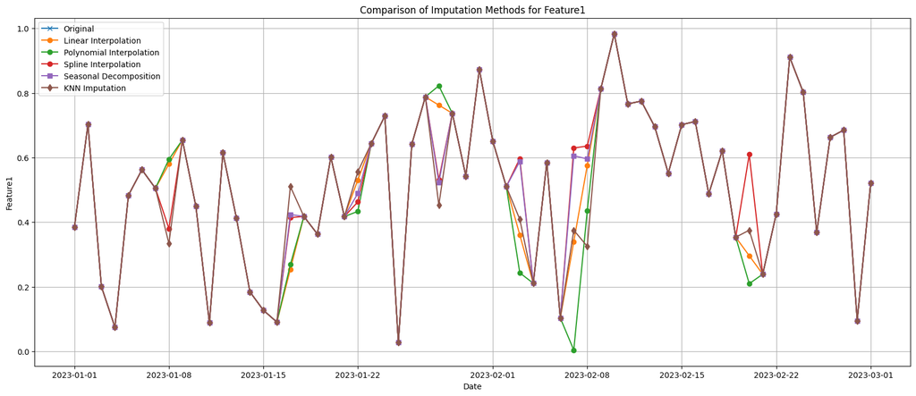

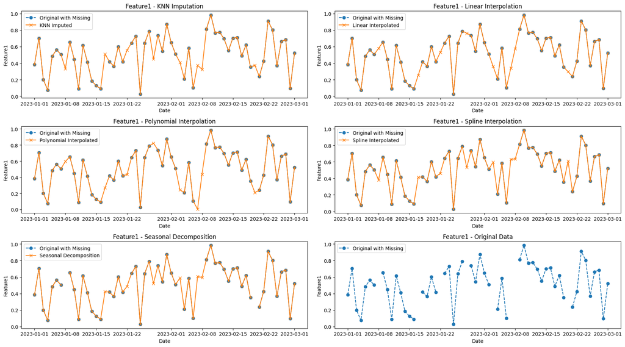

### Compare `Feature 2`

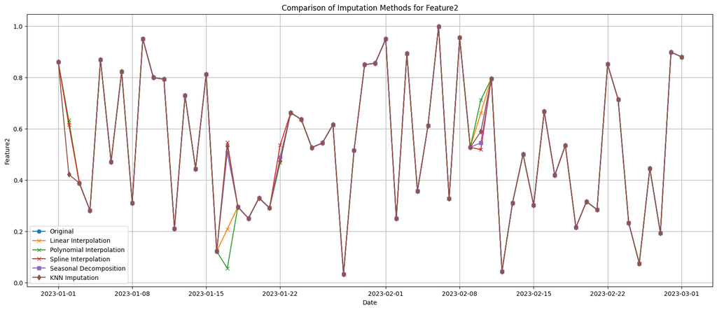

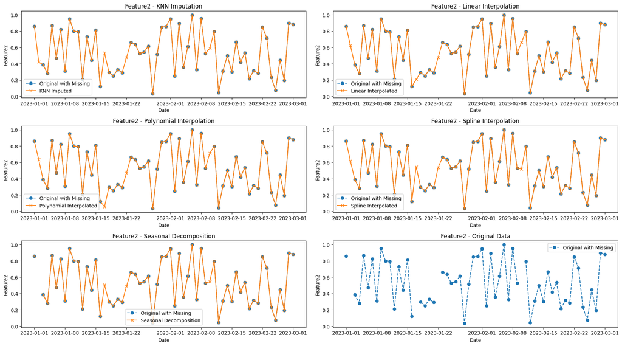

Back to Top